# Reproducible Research: Peer Assessment 1

## Loading and preprocessing the data

Here are the packages I am using for this assignment:

```r
library(tidyverse)
library(lubridate)
```

#### 1 & 2. Here is my code to load and process the data:

```r
setwd("C:/Users/207014104/Desktop/DataScience/Reproduceable Research/Project1/repdata_data_activity")

fileName <- "activity.csv"

#read the csv once it has been unzipped in the working directory
activity <- as_tibble(read.csv(fileName))
```

## What is mean total number of steps taken per day?

#### 1. Calculate the total number of steps taken per day

```r
dailySteps <- group_by(activity, date) %>%
        summarize(totalSteps = sum(steps))
print(dailySteps)
```

```
## # A tibble: 61 x 2
##    date       totalSteps
##    <fct>           <int>
##  1 2012-10-01         NA
##  2 2012-10-02        126
##  3 2012-10-03      11352
##  4 2012-10-04      12116
##  5 2012-10-05      13294
##  6 2012-10-06      15420
##  7 2012-10-07      11015
##  8 2012-10-08         NA
##  9 2012-10-09      12811
## 10 2012-10-10       9900
## # ... with 51 more rows
```

#### 2. Make a histogram of the total number of steps taken each day

[figure not shown]

```r
ggplot(dailySteps, aes(x = totalSteps)) +
        geom_histogram(binwidth = 2500, #set bins to width of 2500 steps
                       fill = "white", #make the fill of bars white
                       color = "black" #make outline of bars black
                       ) +
        labs(title = "Histogram of total steps each day (missing values omitted)",
             x = "Count of days",
             y = "Number of steps per day")
```

#### 3. Calculate and report the mean and median of the total number of steps taken per day

```r
meanOriginal <- mean(dailySteps$totalSteps, na.rm = TRUE)
medianOriginal <- median(dailySteps$totalSteps, na.rm = TRUE)

cat("The mean is:", meanOriginal)
```

```
## The mean is: 10766.19
```

```r
cat("The median is:", medianOriginal)
```

```
## The median is: 10765
```

## What is the average daily activity pattern?

1. Make a time series plot of the 5-minute interval and the average number of steps taken averaged across all days

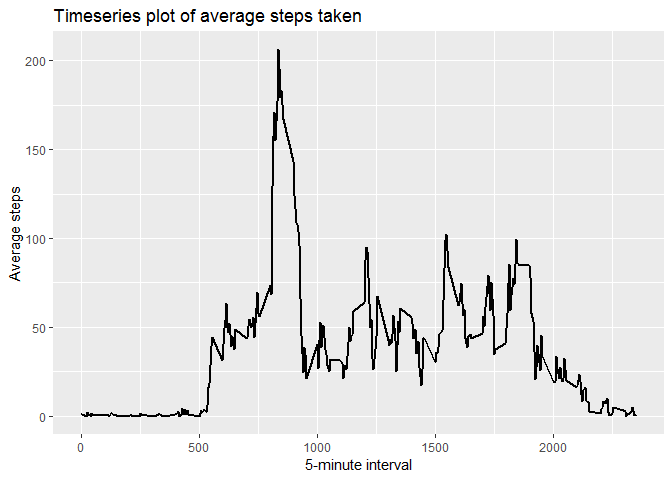

```r
#group the data by interval and summarize by mean steps / interval
dailyProfile <- group_by(activity, interval) %>%
        summarize(intervalSteps = mean(steps, na.rm=TRUE))

# plot the
ggplot(dailyProfile, aes(x = interval, y = intervalSteps)) + geom_line(size = 1) +
        labs(title = "Timeseries plot of average steps taken",
             x = "5-minute interval",
             y = "Average steps")
```

2. Which 5-minute interval contains the maximum number of steps?

```r
max <- dailyProfile[which.max(dailyProfile$intervalSteps),]
print(max)
```

```
## # A tibble: 1 x 2
##   interval intervalSteps
##      <int>         <dbl>
## 1      835          206.
```

```r
cat("The interval with the max average number of steps is", max$interval)
```

```
## The interval with the max average number of steps is 835
```